# Optimal Graduate Schools

Michael McCoy

11/3/2021

# Markowitz’s Efficient Frontier of Optimal Portfolios and Allocation **Graduate Schools**

#### My loose goal is to find the optimal graduate school using R. I thought this would be good practice for an R beginner like me

## Loose Goals:

1. I don’t want a school that is a research mill.
2. Yet, I still want a school that has an impact on research.

There is a delicate trade-off between citations and impact. Here, impact is defined as how many citations a university receives divided by how many total papers each university publishes. The following data on impact and citations is across a five-year span from 2012 through the end of 2016.

The data on total papers reflect journals indexed in the following Web of Science Core Collection editions: Science Citation Index Expanded, Social Sciences Citation Index, and Arts and Humanities Citation Index. Data included herein are derived from Clarivate Analytics InCites. For blank categories, those institutions may have received less than 600 citations over the five-year span from 2012 through the end of 2016.

To begin, let’s load our necessary packages and load my starting data set of universities that I created in Excel

```r
library(tidyverse)
library(readxl)
Graduate_Programs_Copy <- read_excel("data/raw_data/Graduate Programs - Copy.xlsx")
```

Here is a brief summary of the data:

```r
summary(Graduate_Programs_Copy)
```

```
##  Institution        Clinical Psychology Ph.D. PCSAS Accreditation1
##  Length:160         Length:160
##  Class :character   Class :character
##  Mode  :character   Mode  :character
##
##
##
##
##  Clinical Psychology Ph.D. APCS Member Bolder_Boulder_Model   Citations
##  Length:160                            Length:160           Min.   :  600
##  Class :character                      Class :character     1st Qu.: 1323
##  Mode  :character                      Mode  :character     Median : 2459
##                                                             Mean   : 4588
##                                                             3rd Qu.: 6021
##                                                             Max.   :42538
##                                                             NA's   :16
##     Articles          Impact         Valence
##  Min.   : 129.0   Min.   :2.603   Min.   :2.700
##  1st Qu.: 323.8   1st Qu.:3.996   1st Qu.:3.000
##  Median : 523.5   Median :4.799   Median :3.400
##  Mean   : 826.6   Mean   :4.918   Mean   :3.538
##  3rd Qu.:1121.5   3rd Qu.:5.688   3rd Qu.:4.000
##  Max.   :6288.0   Max.   :8.113   Max.   :4.800
##  NA's   :16       NA's   :16      NA's   :31
```

Now I am going to print the names of all the universities in the data set (printing all the other columns won’t fit)

```r
Graduate_Programs_Copy %>%
  select(Institution) %>%
  print(n=Inf)
```

```
## # A tibble: 160 × 1
##     Institution
##     <chr>
##   1 Hofstra University
##   2 Washington University in St. Louis
##   3 Illinois Institute of Technology
##   4 Vanderbilt University
##   5 University of Virginia
##   6 University of Arizona
##   7 University of California, Berkeley
##   8 Duke University
##   9 University of Pennsylvania
##  10 University of California, Los Angeles
##  11 University of California, Santa Barbara
##  12 University of Iowa
```

[output cut: 148 more lines]

Wow, that’s 160 universities. Let’s have some standards. We’ll first filter by ‘Bolder’ Boulder Model programs which are schools that have high research-related accreditation and membership standards. Then, we’ll print the scatter plot of the ‘Bolder’ Boulder institutions: X = Impact, Y = Citations. As a reminder, Impact = Citations/Web of Science Documents). As another reminder, all citations and web of science documents are across a 5 year period from 2012 to the end of 2016.

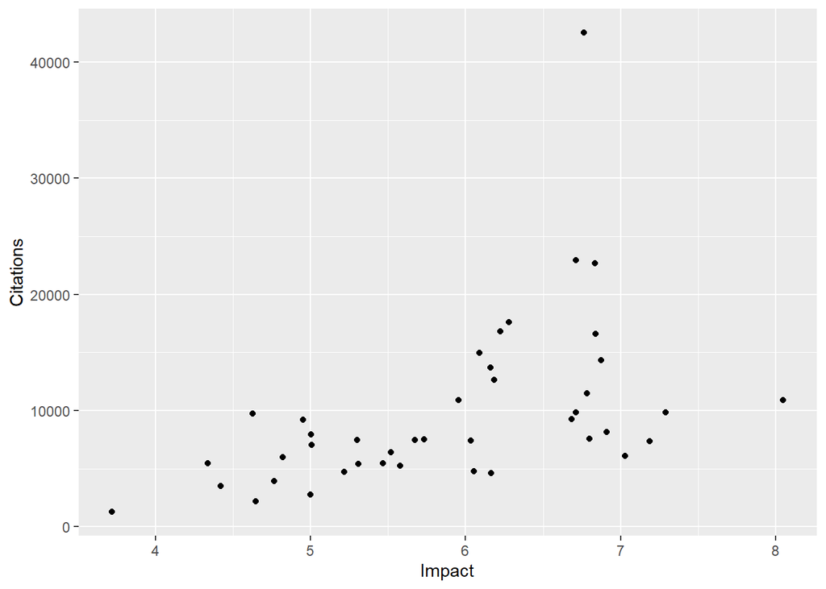

```r
Bolder_Boulder <- Graduate_Programs_Copy %>%
  filter(!is.na(Bolder_Boulder_Model))
ggplot(Bolder_Boulder, aes(Impact, Citations)) +
  geom_point()
```

Based on this ‘Bolder’ Boulder criteria, we go from 160 institutions to 43. Since the data looks like a polynomial function, let’s apply a quadratic regression curve of best fit to the scatter plot.

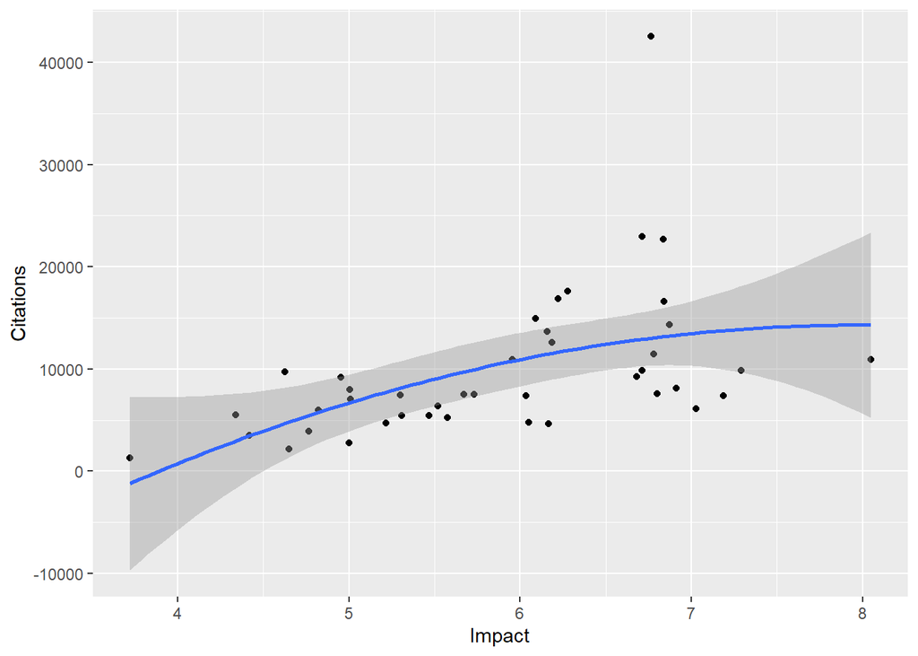

```r
Bolder_Boulder %>%
  ggplot(aes(Impact, Citations)) +
  geom_point() +
  #plot line of best fit using quadratic regression
  geom_smooth(method = "lm", formula = y ~ x + I(x^2))
```

If we were to plot a tangent line, (unfortunately my R knowledge is limited) it would be around x= 6. This tangent line would represent the optimal number of citations and impact. However, now the data doesn’t look like a polynomial function. It looks more like a linear function which would completely alter my goal of optimization. Let’s plot a regression line of best fit and see how it looks.

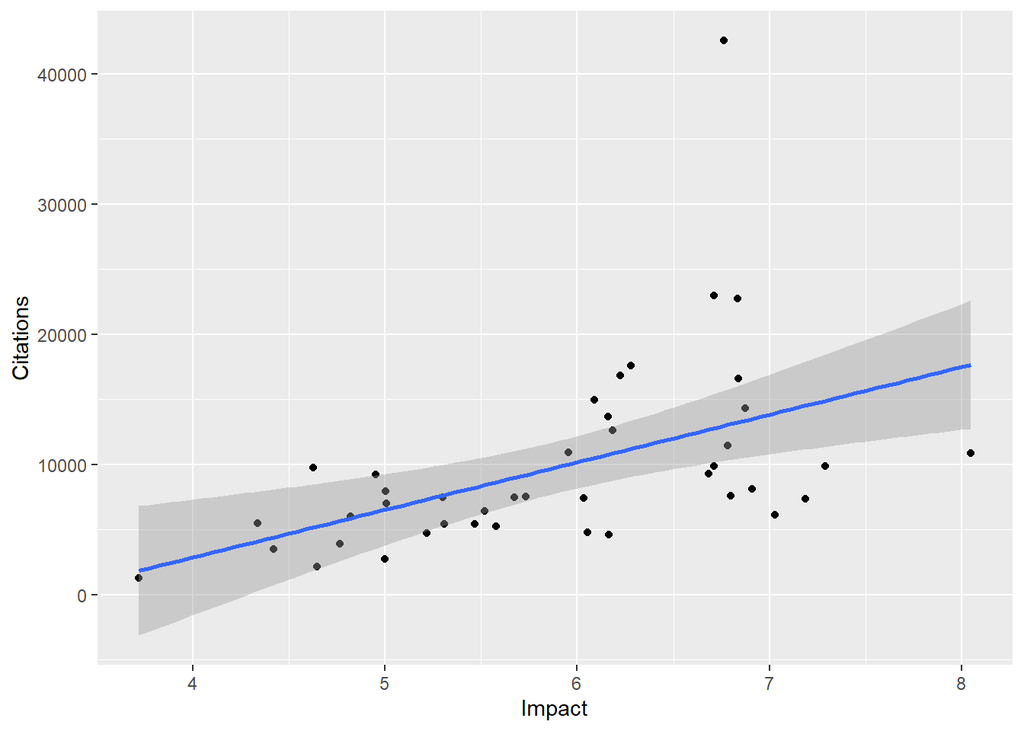

```r
Bolder_Boulder %>%
  ggplot(aes(Impact, Citations)) +
  geom_point() +
  #plot line of best fit using regression
  geom_smooth(method = "lm")
```

Hmmmm. Let’s see the significance of these regression lines.

```r
cor.test(Bolder_Boulder$Impact, Bolder_Boulder$Citations)
```

```
##
##  Pearson's product-moment correlation
##
## data:  Bolder_Boulder$Impact and Bolder_Boulder$Citations
## t = 3.5302, df = 40, p-value = 0.001062
## alternative hypothesis: true correlation is not equal to 0
## 95 percent confidence interval:
##  0.2153567 0.6892222
## sample estimates:
##       cor
## 0.4873868
```

Okay, well, yes it makes sense that they’re correlated because impact is directly derived from citations. Although, now I’m interested in seeing Articles by Citations of our ‘Bolder’ Boulder model universities. Then seeing if that is correlated. In other words, if you have more article publications, are you going to have more people citing those publications? You would certainly hope so as a university, otherwise you’re operating on diminishing returns. Enough chatter, let’s see the data.

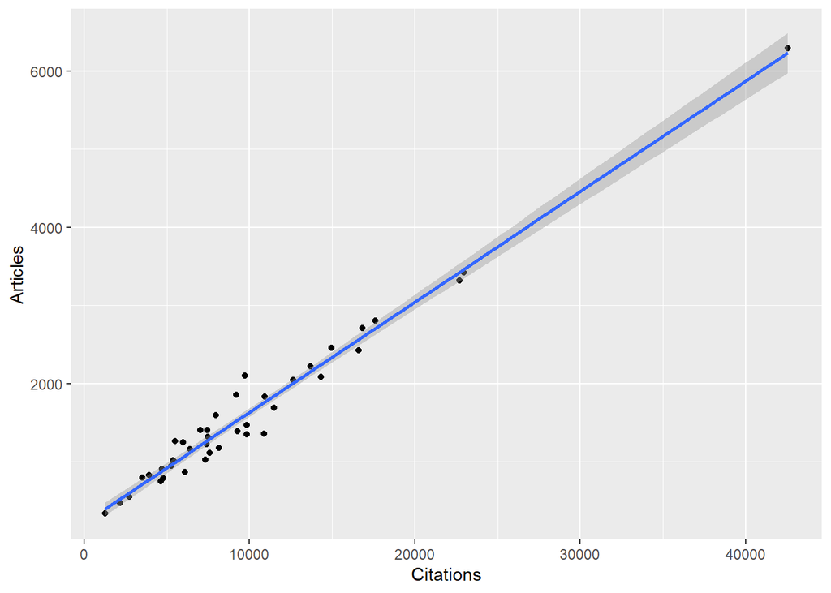

```r
Bolder_Boulder %>%
  ggplot(aes(Citations, Articles)) +
  geom_point() +
  #plot line of best fit using regression
  geom_smooth(method = "lm")
```

```r
cor.test(Bolder_Boulder$Articles, Bolder_Boulder$Citations)
```

```
##
##  Pearson's product-moment correlation
##
## data:  Bolder_Boulder$Articles and Bolder_Boulder$Citations
## t = 37.542, df = 40, p-value < 2.2e-16
## alternative hypothesis: true correlation is not equal to 0
## 95 percent confidence interval:
##  0.9741266 0.9925581
## sample estimates:
##       cor
## 0.9861044
```

Hmmm. Interesting. Those are some pretty compelling results. Articles and citations are strongly correlated at p-value < 2.2e-16.

Nevertheless I digress. Let’s go back to our optimal universities plot from before.

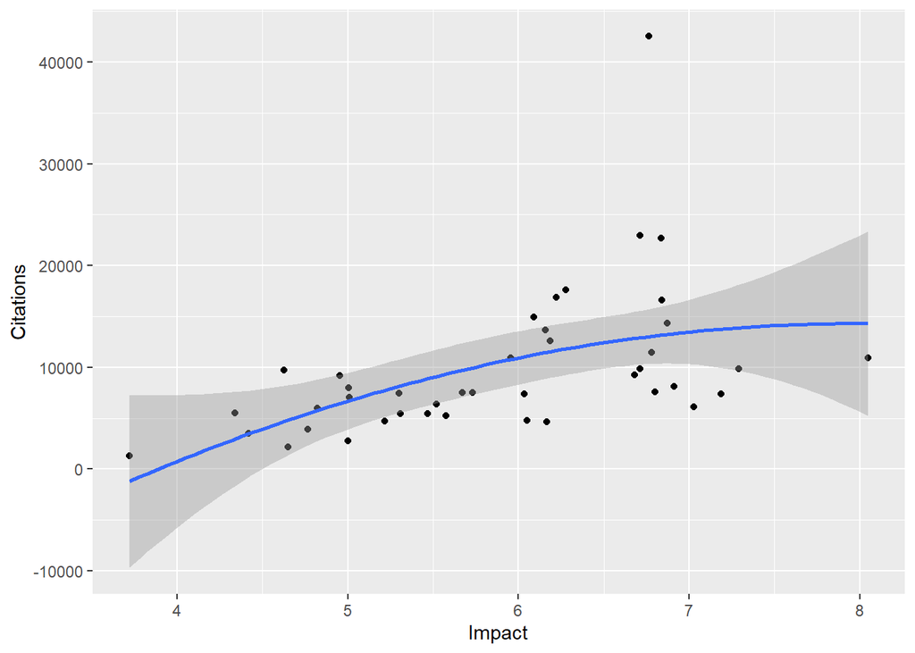

```r
Bolder_Boulder %>%
  ggplot(aes(Impact, Citations)) +
  geom_point() +
  #plot line of best fit using quadratic regression
  geom_smooth(method = "lm", formula = y ~ x + I(x^2))
```

```r
filter(Bolder_Boulder, between(Impact, 5.8, 6.5)) %>%
  select(Institution)
```

```
## # A tibble: 9 × 1
##   Institution
##   <chr>
## 1 University of Pittsburgh
## 2 University of Michigan at Ann Arbor
## 3 University of Washington, Seattle
## 4 University of Oregon
## 5 University of North Carolina at Chapel Hill
## 6 University of Minnesota, Twin Cities
## 7 State University of New York at Stony Brook
## 8 University of Southern California
## 9 Northwestern University
```

I was surprised that local universities, Temple and UPenn, were not one of the 9 universities. After checking the impact number for Temple and Upenn, it was 5.31 and 6.84, respectively. Since the general rule is to apply to 10-12 schools, I decided to expand my impact range to 5.3 to 7. Although, during my grad school search process, I will make reasonable exceptions for other local schools, since I would like to stay local if possible.

```r
filter(Bolder_Boulder, between(Impact, 5.3, 7)) %>%
  select(Institution)
```

```
## # A tibble: 26 × 1
##    Institution
##    <chr>
##  1 University of California, Berkeley
##  2 Duke University
##  3 University of Pennsylvania
##  4 University of California, Los Angeles
##  5 University of Iowa
##  6 Boston University
##  7 Harvard University
##  8 Emory University
##  9 Yale University
## 10 University of Wisconsin, Madison
## # ℹ 16 more rows
```

Now we have 26 options. Okay cool, but Harvard is one of them. Not that it’s a bad thing, but Harvard is an outlier with over 40,000 citations and only an impact of about 6.7. Let’s exclude Harvard.

```r
filter(Bolder_Boulder, between(Impact, 5.3, 7), Citations < 30000) %>%
  select(Institution)
```

```
## # A tibble: 25 × 1
##    Institution
##    <chr>
##  1 University of California, Berkeley
##  2 Duke University
##  3 University of Pennsylvania
##  4 University of California, Los Angeles
##  5 University of Iowa
##  6 Boston University
##  7 Emory University
##  8 Yale University
##  9 University of Wisconsin, Madison
## 10 University of Pittsburgh
## # ℹ 15 more rows
```

Nice, now we are at 25 universities.

Let’s store these universities in a new data frame with the relevant info.

```r
optimal_uni <- filter(Bolder_Boulder, between(Impact, 5.3, 7),
                      Citations < 30000) %>%
  select(Institution, Citations, Articles, Impact, Valence)
```

Let’s print out the data frame that has our optimal universities.

```r
optimal_uni %>% print(n=25)
```

```
## # A tibble: 25 × 5
##    Institution                                 Citations Articles Impact Valence
##    <chr>                                           <dbl>    <dbl>  <dbl>   <dbl>
##  1 University of California, Berkeley               8135     1177   6.91     4.6
##  2 Duke University                                 14336     2086   6.87     4.2
##  3 University of Pennsylvania                      16606     2428   6.84     4.4
##  4 University of California, Los Angeles           22700     3321   6.84     4.8
##  5 University of Iowa                               7574     1114   6.80     4.2
##  6 Boston University                               11463     1690   6.78     4.1
##  7 Emory University                                 9853     1468   6.71     4.2
##  8 Yale University                                 22953     3420   6.71     4.2
##  9 University of Wisconsin, Madison                 9275     1388   6.68     4.5
## 10 University of Pittsburgh                        17605     2804   6.28     4.4
## 11 University of Michigan at Ann Arbor             16839     2706   6.22     4.3
## 12 University of Washington, Seattle               12623     2041   6.18     4.5
## 13 University of Oregon                             4625      750   6.17     4
## 14 University of North Carolina at Chapel Hill     13682     2221   6.16     4.7
## 15 University of Minnesota, Twin Cities            14957     2456   6.09     4.5
## 16 State University of New York at Stony Brook      4787      791   6.05     4.6
## 17 University of Southern California                7399     1226   6.04     4.1
## 18 Northwestern University                         10926     1835   5.95     4.1
## 19 University of Maryland, College Park             7511     1310   5.73     4
## 20 Michigan State University                        7476     1318   5.67     3.8
## 21 University of Georgia                            5265      944   5.58     3.8
## 22 Indiana University at Bloomington                6403     1160   5.52     4.3
## 23 University of Missouri at Columbia               5452      997   5.47     3.8
## 24 Temple University                                5405     1018   5.31     4.3
## 25 University of Illinois at Urbana-Champaign       7455     1406   5.30     4.2
```

```r
mean(optimal_uni$Citations)
```

```
## [1] 10852.2
```

The average number of articles published for our 25 optimum graduate schools across a 5 year span is:

```r
mean(optimal_uni$Articles)
```

```
## [1] 1723
```

In sum, I went from 160 universities to 43 to 25. I did this by first choosing universities that have a Bolder Boulder model for graduate programs which is essentially a model that trains scientific rigor. Next, I plotted the ‘Bolder’ Boulder model universities and applied a linear regression to find the optimal research impact by total number of citations.

# Limitations:

The data is not the most up to date (off by about 5 years). This data is not limited to just psychology departments, it is looking across whole university academic departments. This isn’t the most thorough way of looking at schools, but it is a good start for getting a start at which schools to look at. In the end, I think this was good practice with programming and using R while I looked at grad schools. As you’ll see below, I also had some missing data from some notable R1 universities which could have impacted my total optimal schools.

# Appendum:

After rereading through the code, there were 16 schools that I excluded because they didn’t have any data on citations and consequently impact. Let’s see what schools didn’t have that data:

```r
Graduate_Programs_Copy %>%
  select(Institution, Valence) %>%
  filter(is.na(Graduate_Programs_Copy$Citations))
```

```
## # A tibble: 16 × 2
##    Institution                               Valence
##    <chr>                                       <dbl>
##  1 Brandeis University                          NA
##  2 City University of New York, City College     3
##  3 Columbia University                          NA
##  4 Cornell University                           NA
##  5 Johns Hopkins University                     NA
##  6 Loyola University Maryland                    2.8
##  7 McGill University                            NA
##  8 Mount Sinai Hospital                         NA
##  9 Pepperdine University                        NA
## 10 Ponce Health Sciences University             NA
## 11 Princeton University                         NA
## 12 Rutgers State University at New Brunswick     3.3
## 13 Stanford University                          NA
## 14 University of Chicago                        NA
## 15 University of Maine                           2.9
## 16 University of Toronto                        NA
```

I was curious if I had any valence data on these universities. Unfortunately for what valence data exists, they do not look so good. I suppose I will briefly look at some of these schools during the grad school search process in addition to the optimal schools to be inclusive.